# SageMarkerからDatabricksに接続する

UPDATE: 2024-04-13 02:41:28.653556

Databricksをはじめてさわる機会があったので、自己学習用にAzureでDatabricks環境を構築して、Databricks で遊んでみた。

今回は手元のLocalMacBookのRstudio/Python、それとAWS SageMarkerからAzureDatabricksに接続する方法をまとめている。下記のPOXIT社にドキュメントがあったので、それに沿って進めているだけ。

- [Databricks](https://solutions.posit.co/connections/db/databases/databricks/#databricks-http-path)

## Local R Studio

MacBookProのバーションは下記の通り。

```
% sw_vers
ProductName:    Mac OS X
ProductVersion: 10.15.7
BuildVersion:   19H2026
```

### Driver Options

まずはドライバーをインストールする。Posit Professional Driversが用意されているが、RstudioProでもないので、Databricksが用意しているドライバーをインストールする。

[こちら](https://www.databricks.com/spark/odbc-drivers-download)のURL先に移動して、OSに合わせてドライバーをインストールする。今回は[Mac](https://databricks-bi-artifacts.s3.us-east-2.amazonaws.com/simbaspark-drivers/odbc/2.8.0/SimbaSparkODBC-2.8.0.1002-OSX.zip)用のドライバーをダウンロードする。

```
% ls ~/Downloads
SimbaSparkODBC-2.8.0.1002-OSX.zip
```

解凍してインストールしておく。

### Package Options

使用するパッケージは`odbc`パッケージと`DBI`パッケージの2つ。これらを組み合わせてコネクションを確立する。`odbc`の関数については、`odbc::databricks()`関数が推奨とのこと。

- Using `odbc::databricks()` (Recommended)
- Using `odbc::odbc()`

今回は両方試すことにした。

`databricks()`関数には、必要な接続設定のほとんどを設定するように機能するので便利。`databricks()`関数を実行するために必要な引数は`httpPath`だけで。この引数の値は、Databricks Web UI で取得できる。

[figure not shown]

Connection

[figure not shown]

token

そして、Databricks内の組織のホストURLを`DATABRICKS_HOST`として、環境変数に保存しておく。`usethis::edit_r_environ()`を使用すれば、環境変数ファイルを開くことができる。`databricks()`は、特定の順序で資格情報を検索するため、あわせて環境変数に`DATABRICKS_TOKEN`の情報を登録しておく。最終的な`.Renviron`ファイルは下記の通り。

```
DATABRICKS_DRIVER="/Library/simba/spark/lib/libsparkodbc_sb64-universal.dylib"
DATABRICKS_HOST="adb-<WORKSPACE-ID>.<RANDOM-NUMBER>.azuredatabricks.net"
DATABRICKS_HTTPPATH="/sql/1.0/warehouses/<RANDOMNUMBER-ALPPHABET>"
DATABRICKS_TOKEN="dapid111111111111111111111111"
```

この状態で関数を実行すればOK。ただMacの場合、接続できないケースがあるので、その場合は末尾の方法で修正する。

```
# namespaceを指定しない場合、下記パッケージの読み込み必要
# library(DBI)
# library(odbc)
# library(usethis)

con <- DBI::dbConnect(
  odbc::databricks(),
  httpPath = Sys.getenv("DATABRICKS_HTTPPATH")
)

con
<OdbcConnection> token@Spark SQL
  Database: DatabaseName
  Spark SQL Version: 3.1.1
```

もう1つの方法として、`odbc::odbc()`関数を使用する方法がある。こちらの場合は、下記の通り引数を設定して行う。

- Driver - ドライバーのパスを指定する
- Host - DatabricksのHost URLを指定する
- Port - デフォルトは443
- AuthMech - 認証情報にPATトークンを使用する場合は3を指定する
- HTTPPath - SQL サーバとなるマシンへのパス。Databricks HTTP Pathのこと
- Protocol - デフォルトはhttpsを指定する
- ThriftTransport - デフォルトは2を指定する
- SSL - デフォルトは1を指定する
- UID - AuthMech として 3 を使用する場合、“token” を指定する
- PWD - `DATABRICKS_TOKEN`という環境変数名で取得するのが推奨
- catalog - 必須ではない

この状態で接続すればOK。

```
# namespaceを指定しない場合、下記パッケージの読み込み必要
# library(DBI)
# library(odbc)
# library(usethis)

con <- DBI::dbConnect(
  odbc::odbc(),
  driver = Sys.getenv("DATABRICKS_DRIVER"),
  host = Sys.getenv("DATABRICKS_HOST"),
  port = 443,
  authMech= 3,
  httpPath= Sys.getenv("DATABRICKS_HTTPPATH"),
  protocol= "https",
  thriftTransport = 2,
  ssL  = 1,
  uid = "token",
  pwd  = Sys.getenv("DATABRICKS_TOKEN"),
  catalog = "samples"
)

con
<OdbcConnection> token@Spark SQL
  Database: samples
  Spark SQL Version: 3.1.1
```

あとはSQLを書いて、Rにデータを持ってくれば良い。

```
df <- DBI::dbGetQuery(con, "SELECT c_custkey, c_name, c_nationkey FROM samples.tpch.customer WHERE c_nationkey = 1 LIMIT 10;")
df
   c_custkey             c_name c_nationkey
1     412465 Customer#000412465           1
2     412487 Customer#000412487           1
3     412510 Customer#000412510           1
4     412513 Customer#000412513           1
5     412525 Customer#000412525           1
6     412554 Customer#000412554           1
7     412582 Customer#000412582           1
8     412602 Customer#000412602           1
9     412636 Customer#000412636           1
10    412664 Customer#000412664           1
```

Databricksの管理画面からも接続できていることが確認できる。

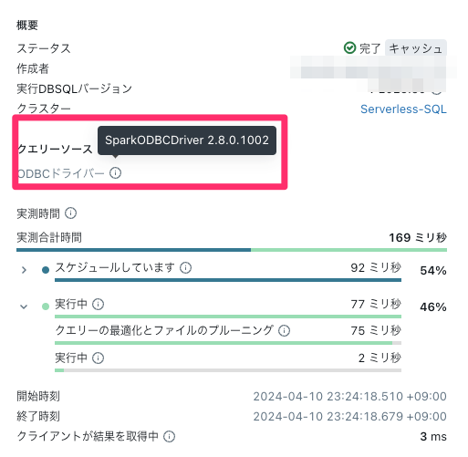

hist

### Troubleshooting: Apple macOS users

このようなエラーが出た場合、修正が必要になる。

```
Unable to locate SQLGetPrivateProfileString function: [Simba][Support] (50483)
Could not load shared library, all attempted paths ("") failed
```

ODBCアプリケーション(R)と ODBCドライバー(新しいDatabricksドライバー)の間のインターフェイスとして機能するODBCドライバーマネージャーをドライバーが見つけられないために発生するとのこと。

この問題を解決するにはステップ踏んで修正していく。まずは、ドライバー マネージャー ライブラリを見つけます。`/usr/local/lib/`フォルダーで`libodbcinst.dylib`というファイルを検索する。

```
% ls /usr/local/lib/libodbcinst.dylib
/usr/local/lib/libodbcinst.dylib@
```

このファイルがそこにない場合は、Homebrewでインストールする。

```
% brew install unixodbc
```

インストール後、次を使用して`brew --prefix unixodbcHomebrew` がインストールされた場所を確認。

```
% brew --prefix unixodbc
/usr/local/opt/unixodbc
```

`libodbcinst.dylib`ファイルは、`lib`サブフォルダー内にある必要がある。ドライバー構成ファイルを開いて編集する。

```
% open /Library/simba/spark/lib/simba.sparkodbc.ini
```

次の2行を最後に追記する。

```
ODBCInstLib=/usr/local/Cellar/unixodbc/2.3.9_1/lib/libodbcinst.dylib
DriverManagerEncoding=UTF-16
```

ちなみにAppleM1シリコンのMacbookは同じ設定でも接続エラーがでて解消できなかった…Ozw

## AWS SageMarker

AWS SageMarker NotebookからDatabricksに接続する方法をまとめておく。まずはNotebookインスタンスを作成し、Notebookを作成する。Notebookの一覧画面、右上のカーネルを選ぶ部分で、terminalを選択する。

```
$ cat /etc/os-release
NAME="Amazon Linux"
VERSION="2"
ID="amzn"
ID_LIKE="centos rhel fedora"
VERSION_ID="2"
PRETTY_NAME="Amazon Linux 2"
ANSI_COLOR="0;33"
CPE_NAME="cpe:2.3:o:amazon:amazon_linux:2"
HOME_URL="https://amazonlinux.com/"
SUPPORT_END="2025-06-30"
```

terminalから下記の操作を行う。やっていることは、先程と同じで、DatabricksのLinux用のドライバー(64bit)をダウンロードして、インストールしている。

```
$ curl -O https://databricks-bi-artifacts.s3.us-east-2.amazonaws.com/simbaspark-drivers/odbc/2.8.0/SimbaSparkODBC-2.8.0.1002-LinuxRPM-64bit.zip
$ unzip SimbaSparkODBC-2.8.0.1002-LinuxRPM-64bit.zip -d /opt
$ sudo rpm -ivh /opt/simbaspark-2.8.0.1002-1.x86_64.rpm
```

`DATABRICKS_DRIVER`は`/opt/`ディレクトリの`.so`ファイルなので注意。

```
$ ls /opt/simba/spark/lib/64/libsparkodbc_sb64.so
```

これらの情報を`.Renviron`に書き込んでおく。

```
$ vim /home/ec2-user/.Renviron

DATABRICKS_DRIVER="/opt/simba/spark/lib/64/libsparkodbc_sb64.so"
DATABRICKS_HOST="adb-<WORKSPACE-ID>.<RANDOM-NUMBER>.azuredatabricks.net"
DATABRICKS_HTTPPATH="/sql/1.0/warehouses/<RANDOMNUMBER-ALPPHABET>"
DATABRICKS_TOKEN="dapid111111111111111111111111"
```

NotebookからDatabricksに接続する際に、`odbc`パッケージが必要になるが、Linuxの場合、下記をインストールしておかないと、`odbc`パッケージのインストールでコケてしまうので注意。

```
$ sudo yum update
$ sudo yum install unixODBC unixODBC-devel -y
```

準備ができたら、Notebookにアクセスする。そして、コネクションを確立してSQLでデータを引き込む。

```
# install.packages("odbc")
# install.packages("DBI")

library(odbc)
library(DBI)

con <- DBI::dbConnect(
  odbc::databricks(),
  httpPath = Sys.getenv('DATABRICKS_HTTPPATH')
)
con
<OdbcConnection> token@Spark SQL
  Database: dbw_sql_dev_ja
  Spark SQL Version: 3.1.1

sql <- '
SELECT
    c_custkey
    , c_name
    , c_nationkey
FROM
    samples.tpch.customer
WHERE
    c_nationkey = 1
LIMIT 10
;'

df <- DBI::dbGetQuery(con, sql)
df

c_custkey                 c_name    c_nationkey
   412465     Customer#000412465              1
   412487     Customer#000412487              1
   412510     Customer#000412510              1
   412513     Customer#000412513              1
   412525     Customer#000412525              1
   412554     Customer#000412554              1
   412582     Customer#000412582              1
   412602     Customer#000412602              1
   412636     Customer#000412636              1
   412664     Customer#000412664              1

dbDisconnect(con)
```

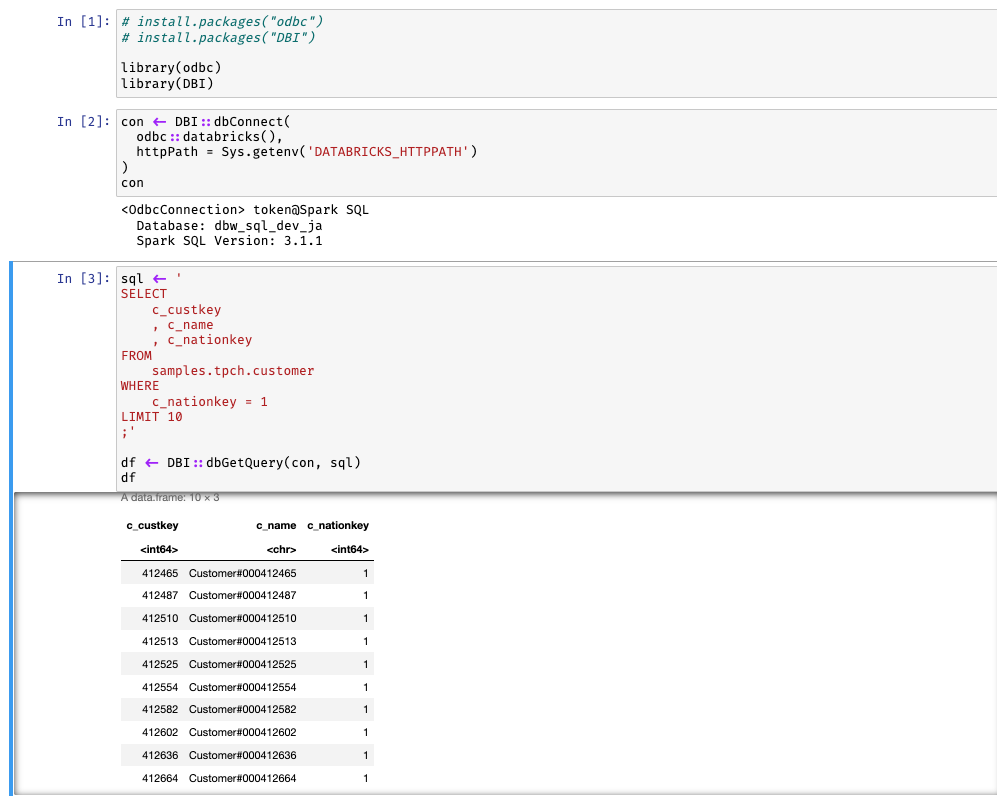

SageMarker

## おまけ

Pythonで接続する方法。

```
from databricks import sql
import os
import pandas as pd

connection = sql.connect(
  server_hostname = "adb-<WORKSPACE-ID>.<RANDOM-NUMBER>.azuredatabricks.net",
  http_path = "/sql/1.0/warehouses/<RANDOMNUMBER-ALPPHABET>",
  access_token = "dapid111111111111111111111111"
  )

cursor = connection.cursor()

cursor.execute("select o_custkey, o_orderdate, row_number() over(partition by o_custkey order by o_orderdate desc) as ind from samples.tpch.orders qualify ind in (1,2,3) limit 10")
rows = cursor.fetchall()
df = pd.DataFrame(rows)
column_names = [description[0] for description in cursor.description]
df.columns = column_names

df
   o_custkey o_orderdate  ind
0         28  1998-02-18    1
1         28  1997-05-31    2
2         28  1997-04-21    3
3         29  1998-03-21    1
4         29  1997-01-18    2
5         29  1995-07-30    3
6        151  1998-06-06    1
7        151  1998-05-30    2
8        151  1996-12-10    3
9        200  1997-10-06    1

cursor.close()
connection.close()
```

## :closed_book: Reference

- [Databricks](https://solutions.posit.co/connections/db/databases/databricks/#databricks-http-path)